# Textual statistics

Constantine Boussalis

1 February 2022

### Overview

This tutorial covers a variety of textual statistics that can be performed on a corpus using quanteda. Specifically, we will discuss basic frequency analysis and how to visualize these results to answer various questions. Next, we will cover the *keyness* of features in a comparative context. Then we will dive into how to estimate the complexity of text via readability and lexical diversity scores. Lastly, we will cover text similarity metrics; specifically focusing on *cosine similarity*. The tutorial will use the 2017 UN General Assembly speeches as the working corpus.

### Load 2017 UN General Assembly speeches

Let’s first load the data-feature matrix that we constructed in our previous tutorial. First, let’s make sure we have the `quanteda.corpora` package.

```
require(devtools)
devtools::install_github("quanteda/quanteda.corpora")
```

Now let’s load the UNGA speeches from `quanteda.corpora`

```r
library(quanteda)
library(quanteda.corpora)
un_corpus <- corpus(data_corpus_ungd2017)
summary(un_corpus, 15)
```

```
## Corpus consisting of 196 documents, showing 15 documents:
##
##                  Text Types Tokens Sentences country_iso un_session year
##           Afghanistan   781   2059        86         AFG         72 2017
##                Angola   681   1938        59         AGO         72 2017
##               Albania   838   2277        88         ALB         72 2017
##               Andorra   888   2816        90         AND         72 2017
##  United Arab Emirates   759   2367        78         ARE         72 2017
##             Argentina   834   2450        90         ARG         72 2017
##               Armenia   685   1844        78         ARM         72 2017
##     Antigua & Barbuda   894   2585       103         ATG         72 2017
##             Australia   694   1848        92         AUS         72 2017
##               Austria   544   1460        75         AUT         72 2017
##            Azerbaijan   755   2086        93         AZE         72 2017
##               Burundi   756   1974        78         BDI         72 2017
##               Belgium   829   2088       102         BEL         72 2017
##                 Benin   504   1307        43         BEN         72 2017
##          Burkina Faso   738   1951        65         BFA         72 2017
##               country continent          gdp gdp_per_capita
##           Afghanistan      Asia 1.954398e+10            550
##                Angola    Africa 1.221238e+11           4100
##               Albania    Europe 1.303854e+10           4538
##               Andorra    Europe 3.012914e+09          39147
##  United Arab Emirates      Asia 3.825751e+11          40699
##             Argentina  Americas 6.374303e+11          14398
##               Armenia      Asia 1.153659e+10           3937
##     Antigua & Barbuda  Americas 1.510085e+09          14803
##             Australia   Oceania 1.323421e+12          53800
##               Austria    Europe 4.165957e+11          47291
##            Azerbaijan      Asia 4.074779e+10           4132
##               Burundi    Africa 3.172416e+09            292
##               Belgium    Europe 4.926813e+11          43324
##                 Benin    Africa 9.246697e+09            827
##          Burkina Faso    Africa 1.232286e+10            642
```

#### Text processing and creation of DFM

Let’s process the text of the speeches using the same methods we learned in our previous tutorial. We will not stem, but will replace collocations.

```r
require(quanteda.textstats)
toks <- tokens(un_corpus,
               include_docvars = TRUE) %>%
  tokens_tolower() %>%
  tokens_remove(stopwords("english"), padding = TRUE) %>%
  tokens_remove('[\\p{P}\\p{S}]', valuetype = 'regex', padding = TRUE)

unsup_col <- textstat_collocations(toks,
                                   method = "lambda",
                                   size = 2,
                                   min_count = 5,
                                   smoothing = 0.5)

unsup_col <- unsup_col[order(-unsup_col$count),] # sort detected collocations by count (descending)
toks <- tokens_compound(toks, pattern = unsup_col[unsup_col$z > 10])
toks <- tokens_remove(tokens(toks), "") # let's also remove the whitespace placeholders

toks <- tokens(toks,
               remove_numbers = TRUE,
               remove_punct = TRUE,
               remove_symbols = TRUE,
               remove_hyphens = TRUE,
               remove_separators = TRUE,
               remove_url = TRUE,
               include_docvars = TRUE)
```

Let’s do a before and after on one of the speeches. Let’s see the original text of Russia’s speech. First, let’s determine what variable contains the names of the countries.

```r
names(docvars(un_corpus))
```

```
## [1] "country_iso"    "un_session"     "year"           "country"
## [5] "continent"      "gdp"            "gdp_per_capita"
```

We can subset the corpus to only include speeches from Russia and create a new (smaller) corpus object.

```r
russia_text <- corpus_subset(un_corpus, country == "Russia")
substr(as.character(russia_text), 1, 1000) # print first 1000 characters of speech
```

```
##                                                                                                                                                                                                                                                                                                          …
## "In December of last year, the General Assembly adopted resolution 71/190, on the promotion of a democratic and equitable international order, which clearly stipulated the inadmissibility of interference in the internal affairs of States and of coups d'état as a method of transferring power, and …
```

And next, let’s look at the processed text.

```r
toks[["Russia"]][1:100]
```

```
##   [1] "december"                "last_year"
##   [3] "general_assembly"        "adopted"
##   [5] "resolution_71"           "promotion"
##   [7] "democratic"              "equitable"
##   [9] "international_order"     "clearly"
##  [11] "stipulated"              "inadmissibility"
##  [13] "interference"            "internal_affairs"
##  [15] "states"                  "coups"
##  [17] "method"                  "transferring"
##  [19] "power"                   "importance"
##  [21] "excluding"               "international_relations"
##  [23] "certain"                 "states"
##  [25] "efforts"                 "exert"
##  [27] "unlawful"                "pressure"
##  [29] "others"                  "including"
```

[output cut: 35 more lines]

Now let’s create a DFM with this `tokens` object.

```r
dfm_un <- dfm(toks) # create a DFM
dfm_un
```

```
## Document-feature matrix of: 196 documents, 14,089 features (95.49% sparse) and 7 docvars.
##                       features
## docs                   stand general_assembly_today reminded wise men women
##   Afghanistan              2                      1        1    1   2     9
##   Angola                   0                      0        0    0   0     0
##   Albania                  0                      0        0    0   0     4
##   Andorra                  0                      0        0    0   0     0
##   United Arab Emirates     4                      0        0    1   0     2
##   Argentina                0                      0        0    0   0     5
##                       features
## docs                   displayed unique capacity learn
##   Afghanistan                  1      3        1     1
##   Angola                       0      0        0     0
##   Albania                      0      0        0     0
##   Andorra                      0      0        1     0
##   United Arab Emirates         0      0        0     0
##   Argentina                    0      0        0     0
## [ reached max_ndoc ... 190 more documents, reached max_nfeat ... 14,079 more features ]
```

### Frequency analysis

We can perform a number of simple frequency analyses to get a sense of the most talked about terms. How about the top 30 from all speeches:

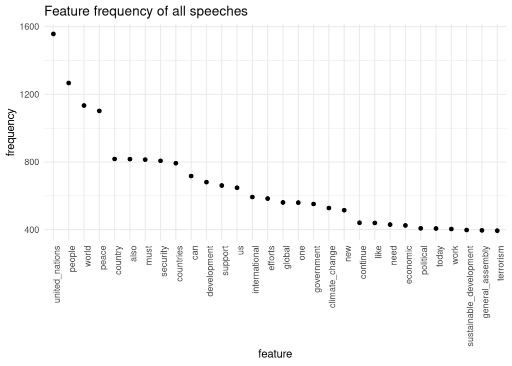

```r
library(ggplot2)

dfm_freq <- textstat_frequency(dfm_un, n = 30)
# sort features by frequency in descending order
dfm_freq$feature <- with(dfm_freq, reorder(feature, -frequency))
# plot feature frequencies
ggplot(dfm_freq, aes(x = feature, y = frequency)) + ggtitle("Feature frequency of all speeches") +
       geom_point() + theme_minimal() + theme(axis.text.x = element_text(angle = 90, hjust = 1))
```

Instead of all speeches, we can also look at the feature frequency of the Russian speech.

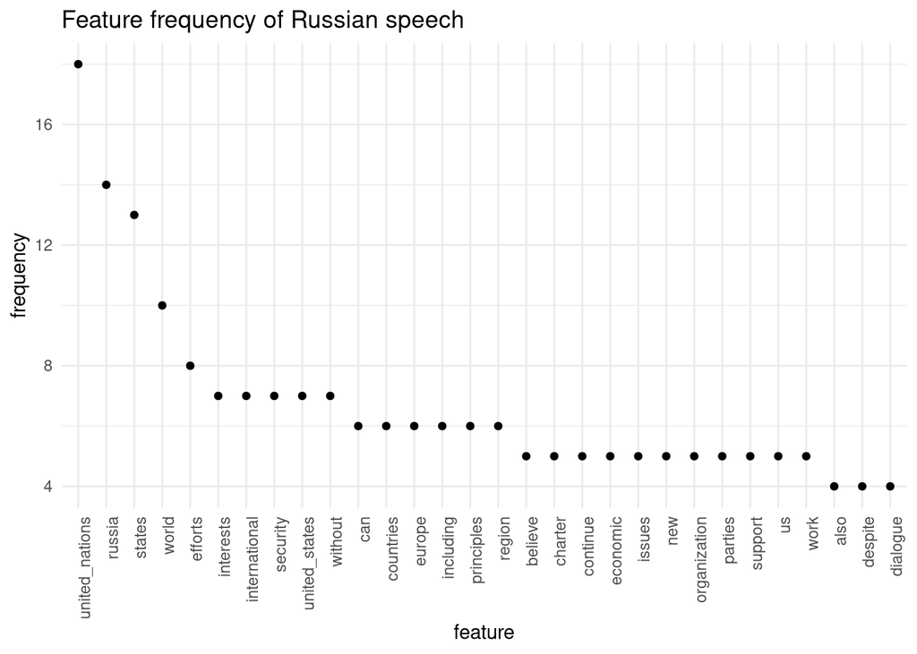

```r
library(ggplot2)

dfm_russia <- dfm_subset(dfm_un, country == "Russia")
dfm_freq <- textstat_frequency(dfm_russia, n = 30)
# sort features by frequency in descending order
dfm_freq$feature <- with(dfm_freq, reorder(feature, -frequency))
# plot feature frequencies
ggplot(dfm_freq, aes(x = feature, y = frequency)) + ggtitle("Feature frequency of Russian speech") +
       geom_point() + theme_minimal() + theme(axis.text.x = element_text(angle = 90, hjust = 1))
```

We can also generate a comparison cloud which displays highly frequent words in a wordcloud for up to eight documents. Let’s compare the most frequent features from the speeches of Russia, China, and the United States.

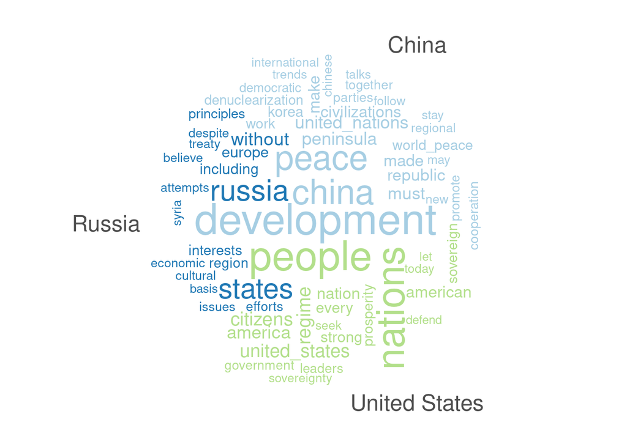

```r
require(quanteda.textplots)
dfm_comparison <- dfm_subset(dfm_un, country %in% c("Russia", "China", "United States"))

set.seed(1234)
textplot_wordcloud(dfm_comparison, max_words = 65, comparison = TRUE)
```

We can also compare the top features of high income and non-high income countries. Let’s create a document-level dummy variable for income level and then plot a comparison word cloud.

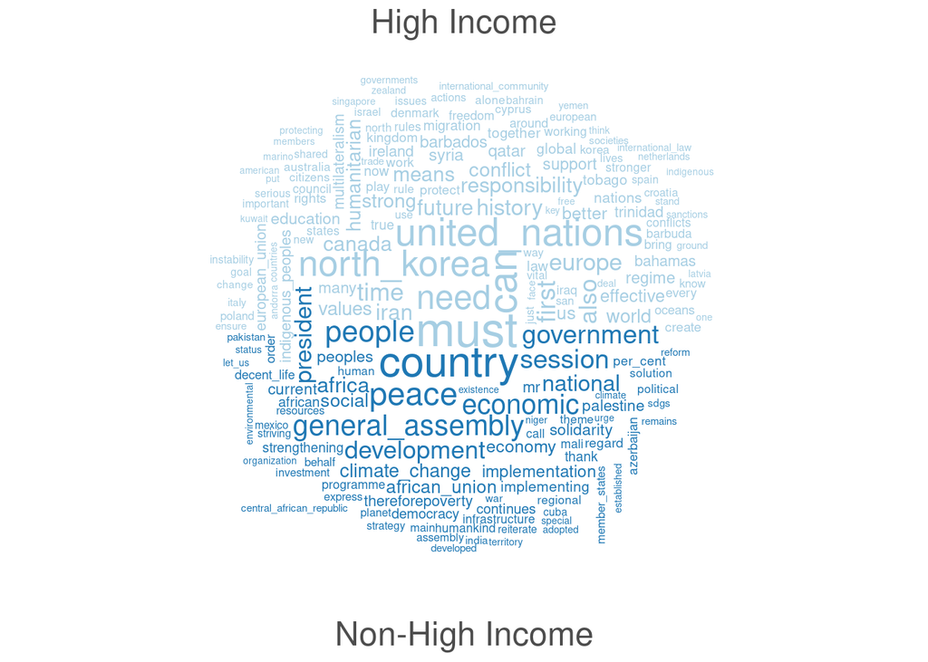

```r
# add income dummy variable to DFM
docvars(dfm_un, "dummy_income") <- factor(ifelse(docvars(dfm_un, "gdp_per_capita") > 12500, "High Income", "Non-High Income"))

# create new dfm based on income groups and plot comparison wordcloud
dfm_income <- dfm_subset(dfm_un, dummy_income %in% c("High Income", "Non-High Income"))
dfm_income <- dfm_group(dfm_income, groups = dummy_income)
textplot_wordcloud(dfm_income, comparison = TRUE, max_words = 200, min_size = 0.2, max_size = 3, fixed_aspect = FALSE)
```

### Keyness

Keyness is a measure that takes into account the extent to which features are specific to a particular document (or group of documents) when compared to the remaining corpus, while accounting for the fact that some features might be too rare. We can, therefore, identify frequent words in documents found in a “target” and “reference” group.

Let’s perform a relative frequency analysis between the speech of the United States (Trump) and that of China (Xi Jinping).

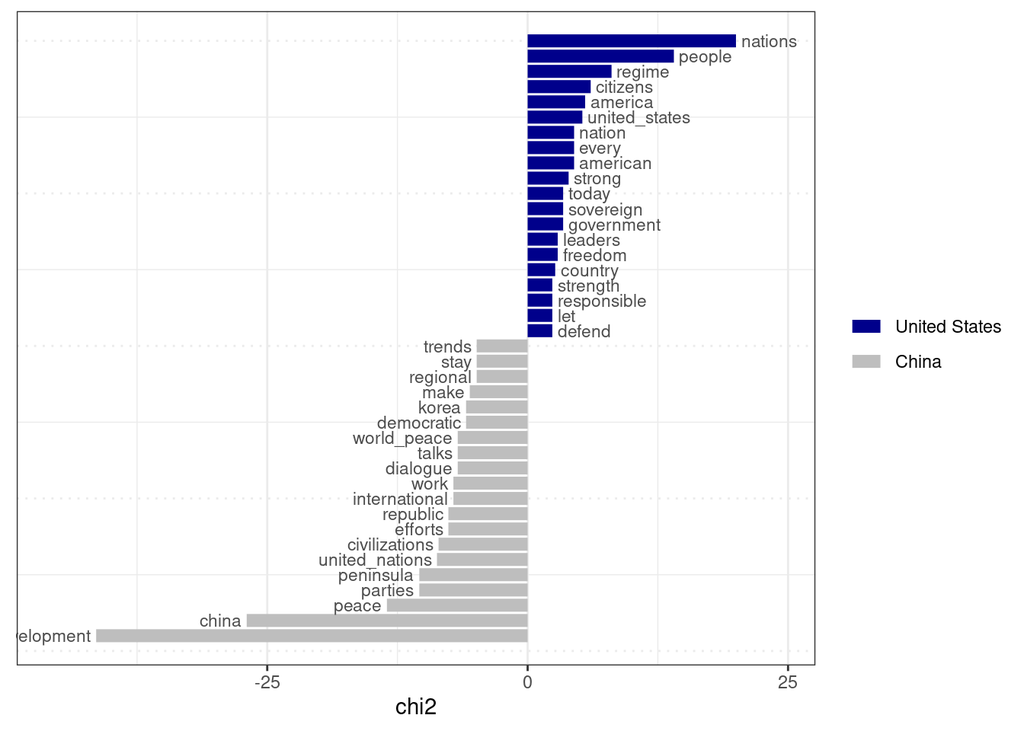

```r
dfm_keyness <- dfm_subset(dfm_un, country %in% c("United States", "China"))
dfm_keyness <- dfm_group(dfm_keyness, groups = country)

# Calculate keyness and set the United States (Donald Trump) as the target group
keyness_stat <- textstat_keyness(dfm_keyness, target = "United States")

# Plot keyness calculations
textplot_keyness(keyness_stat, labelsize = 3)
```

### Readability/Lexical Diversity

We can also approximate how complex a given speech is. One approach is to rely on readability scores. There are a whole range of readability measures available to us and offered by the quanteda library. Let’s use the Flesch-Kincaid measure on the UNGA speeches. Note that we will pass the original corpus to calculate the readability of the speeches. Then we will compare the readability of a select number of countries.

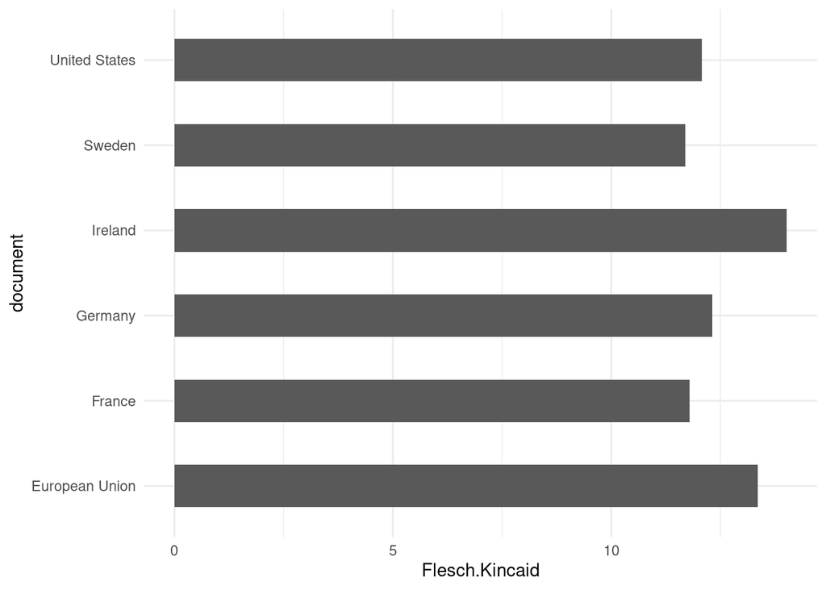

```r
rd <- textstat_readability(un_corpus, measure = "Flesch.Kincaid") # calculate readability scores
rd_subset <- dplyr::filter(rd, document %in% c("United States", "European Union", "Germany", "Ireland", "France", "Sweden"))

#plot readability of subset
ggplot(rd_subset, aes(x = document, y = Flesch.Kincaid)) +
  geom_bar(stat = "identity", width=0.5) +
  theme_minimal() +
  coord_flip()
```

It looks like Trump is not as simple as one might think! :) What if we use a simple measure of lexical diversity (TTR)? Note that here we will use the DFM as input.

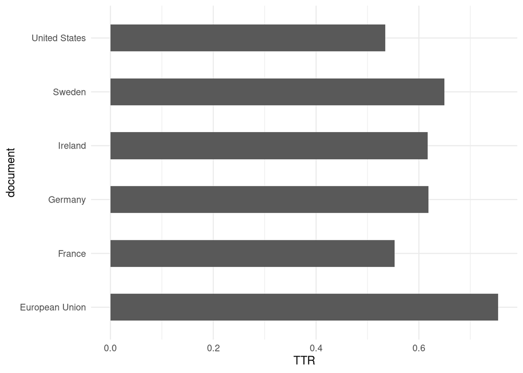

```r
ld <- textstat_lexdiv(dfm_un, measure = "TTR") # calculate lexical diversity score
ld_subset <- dplyr::filter(ld, document %in% c("United States", "European Union", "Germany", "Ireland", "France", "Sweden"))

#plot lexical diversity of subset
ggplot(ld_subset, aes(x = document, y = TTR)) +
  geom_bar(stat = "identity", width=0.5) +
  theme_minimal() +
  coord_flip()
```

However, if we use this measure of complexity, we see that the United States is the most simple of the set of leader speeches.

### Text similarity using cosine similarity

We can calculate similarity metrics to determine documents that are similar to eachother based on their feature frequencies. In quanteda we can use `textstat_simil` to calculate *cosine similarity* which is a popular such metric.

Note that we will weight the DFM by term frequency-inverse document frequency (tf-idf) instead of just relying on term frequency. The higher the tf-idf weight, the more rare the token. This weighting helps up-weight more predictive tokens.

Let’s determine which leaders’ speeches were closest to that of the United States (2017).

```r
dfm_un_tfidf <- dfm_tfidf(dfm_un)
cosine_sim <- textstat_simil(dfm_un_tfidf, margin="documents", method="cosine")
cosine_sim_list <- as.list(cosine_sim)


cosine_sim_usa <- cosine_sim_list["United States"]
head(cosine_sim_usa$`United States`, 20) # display top 20 most similar speeches
```

```
##       United Kingdom            Venezuela                 Cuba
##           0.17429871           0.16095896           0.15748504
##               France                 Iran               Israel
##           0.14165989           0.14107526           0.14046770
##                Syria               Russia          North Korea
##           0.13475023           0.12419300           0.12361979
## United Arab Emirates              Bahrain             Slovakia
##           0.11477373           0.11383380           0.11373773
##              Germany                Yemen           Costa Rica
##           0.11338447           0.10979264           0.10764092
##              Belgium              Bolivia                Egypt
##           0.10683563           0.10612651           0.10441559
##          Afghanistan                 Fiji
##           0.10269495           0.09822392
```

```r
tail(cosine_sim_usa$`United States`, 20) # display 20 least similar speeches
```

```
##             Algeria Congo - Brazzaville            Mongolia                Peru
##          0.04038747          0.03985287          0.03901134          0.03878426
##           Mauritius            Barbados               Malta          Cape Verde
##          0.03814991          0.03654189          0.03635962          0.03616913
##              Rwanda           Indonesia               Benin             Finland
##          0.03597333          0.03524193          0.03294419          0.03281995
##          Madagascar                Laos             Moldova               Tonga
##          0.03197984          0.03114687          0.02895131          0.02633396
##          Montenegro             Armenia        Turkmenistan   Trinidad & Tobago
##          0.02598987          0.02333466          0.02276605          0.02068488
```

How about China?

```r
cosine_sim_china <- cosine_sim_list["China"]
head(cosine_sim_china$`China`, 20) # display top 20 most similar speeches
```

```
##         Russia        Belarus    North Korea           Oman    South Korea
##     0.13489176     0.11409224     0.11045624     0.10812507     0.10166789
##        Belgium  United States         France      Macedonia        Germany
##     0.10082880     0.09085205     0.08795949     0.08742000     0.08675319
##     Luxembourg          Egypt United Kingdom         Brazil          Spain
##     0.08419693     0.08363262     0.08159745     0.08079900     0.07775290
##     Kazakhstan     Costa Rica        Vietnam         Guinea   Burkina Faso
##     0.07707406     0.07619249     0.07525962     0.07480535     0.07449477
```

```r
tail(cosine_sim_china$`China`, 20) # display 20 least similar speeches
```

```
##             Uganda             Malawi             Zambia              Benin
##         0.03219724         0.03190090         0.03144631         0.03050901
##          Lithuania            Moldova         Madagascar         Montenegro
##         0.03039874         0.03007565         0.02994555         0.02866379
##           Barbados             Guyana         Cape Verde           Cameroon
##         0.02847101         0.02825332         0.02820097         0.02799210
## Dominican Republic              Malta       Turkmenistan              Tonga
##         0.02757210         0.02684267         0.02660964         0.02594422
##            Grenada         Azerbaijan            Armenia  Trinidad & Tobago
##         0.02437133         0.02077914         0.01795366         0.01613178
```

Iran?

```r
cosine_sim_iran <- cosine_sim_list["Iran"]
head(cosine_sim_iran$`Iran`, 20) # display top 20 most similar speeches
```

```
##               Israel              Bahrain        United States
##           0.20886211           0.14541366           0.14107526
## United Arab Emirates               France                Yemen
##           0.11324045           0.09186007           0.09097075
##                 Cuba               Russia              Germany
##           0.08885684           0.08516035           0.08433604
##              Belgium               Jordan           Costa Rica
##           0.08374597           0.07956631           0.07416373
##           Luxembourg            Venezuela          Afghanistan
##           0.07310515           0.07156081           0.07053733
##                China                 Iraq         Saudi Arabia
##           0.06891760           0.06770674           0.06452468
##                Egypt          South Korea
##           0.06149683           0.06133032
```

```r
tail(cosine_sim_iran$`Iran`, 20) # display 20 least similar speeches
```

```
##               Chad          Mauritius             Uganda             Guyana
##         0.02574910         0.02530974         0.02503084         0.02500377
##              Malta        Switzerland            Moldova         Cape Verde
##         0.02461403         0.02405345         0.02349058         0.02337556
## Dominican Republic            Czechia           Barbados       Turkmenistan
##         0.02240355         0.02233589         0.02158452         0.02093112
##            Grenada               Laos         Montenegro              Benin
##         0.02053369         0.01994822         0.01937668         0.01928361
##             Malawi             Rwanda              Tonga  Trinidad & Tobago
##         0.01845068         0.01841466         0.01723832         0.01348867
```

Japan seems to be very different from many of the states we looked at. Who is closest to them?

```r
cosine_sim_japan <- cosine_sim_list["Japan"]
head(cosine_sim_japan$`Japan`, 20) # display top 20 most similar speeches
```

```
##      South Korea      North Korea      New Zealand        Australia
##       0.14970460       0.10865952       0.09879959       0.08417326
##            Palau    United States           France            China
##       0.08334960       0.08131511       0.07082344       0.06704278
##          Germany         Botswana           Russia   United Kingdom
##       0.06288227       0.06166798       0.06147432       0.05992384
##   European Union        Lithuania          Belgium        Argentina
##       0.05873933       0.05534722       0.05316391       0.04978079
##           Uganda Marshall Islands           Israel          Finland
##       0.04949902       0.04887239       0.04756830       0.04676143
```

```r
tail(cosine_sim_japan$`Japan`, 20) # display 20 least similar speeches
```

```
##             Guyana            Bahamas Dominican Republic            Liberia
##        0.016458187        0.016372718        0.016345757        0.016102123
##               Laos         Madagascar        Switzerland           Cambodia
##        0.016081408        0.016055046        0.015940062        0.015785978
##            Algeria           Pakistan            Morocco             Brunei
##        0.015003665        0.014965497        0.014901007        0.014251202
##       Turkmenistan          Sri Lanka            Grenada            Armenia
##        0.013880708        0.013555181        0.013548218        0.013119614
##              Tonga           Barbados            Czechia  Trinidad & Tobago
##        0.012305329        0.011074126        0.010718428        0.009475843
```